# Question 1: Areal Data (40 marks)

Shared with you are two files:

1. “covid.Rdata” gives various covid related observations aggregated at county level in Michigan taken from New York Times. The variables are:
1. TOT_CASES: total cases
2. CASES_100K: cases per 100,000 population
3. TOT_DEATHS: total deaths
4. DEATHS_100K: deaths per 100,000 population
5. PCT_VACC: vaccination take-up rate.
2. “mi_county” shapefile for the boundaries. Michigan is the only state to consist of two peninsulas. The Lower Peninsula is shaped like a mitten. The Upper Peninsula (often called “the U.P.”) is separated from the Lower Peninsula by the Straits of Mackinac, a five-mile (8 km) channel that joins Lake Huron to Lake Michigan.

```r
library(sf); library(tmap); library(spdep); library(spatialreg)
```

Answer the following questions:

1. Load the Michigan county shapefile and give a “nb” connectivity plot based on the queen contiguity criterion. (4 marks)

```r
#####################
# Michigan counties #
#####################

(mi_county = st_read("mi_county.shp"))
```

```
## Simple feature collection with 83 features and 6 fields
## Geometry type: MULTIPOLYGON
## Dimension:     XY
## Bounding box:  xmin: 161503.6 ymin: 128066.9 xmax: 792243.2 ymax: 856671.3
## Projected CRS: NAD83 / Michigan Oblique Mercator
## First 10 features:
##    OBJECTID    NAME CNTY_CODE     SQKM    LAYOUT PENINSULA
## 1         1  Alcona       001 1798.557 landscape     lower
## 2         2   Alger       003 2424.879 landscape     upper
## 3         3 Allegan       005 2180.969 landscape     lower
## 4         4  Alpena       007 1539.373 landscape     lower
## 5         5  Antrim       009 1358.721 landscape     lower
## 6         6  Arenac       011  952.628 landscape     lower
## 7         7  Baraga       013 2374.275  portrait     upper
## 8         8   Barry       015 1493.487 landscape     lower
## 9         9     Bay       017 1163.246  portrait     lower
## 10       10  Benzie       019  899.702 landscape     lower
##                          geometry
## 1  MULTIPOLYGON (((666667.5 48...
## 2  MULTIPOLYGON (((414149.4 66...
## 3  MULTIPOLYGON (((537474.7 20...
## 4  MULTIPOLYGON (((711456.1 48...
## 5  MULTIPOLYGON (((590912.3 47...
## 6  MULTIPOLYGON (((667849.8 37...
## 7  MULTIPOLYGON (((337205 6541...
## 8  MULTIPOLYGON (((537056.1 24...
## 9  MULTIPOLYGON (((647200 3654...
## 10 MULTIPOLYGON (((514322.4 44...
```

```r
table(st_is_valid(mi_county))
```

```
##
## TRUE
##   83
```

```r
tm_shape(mi_county) + tm_polygons() + tm_layout(main.title="Michigan, USA")
```

[interactive chart not shown]

```r
####################
# Queen contiguity #
####################

(mi_nb = poly2nb(mi_county))
```

```
## Neighbour list object:
## Number of regions: 83
## Number of nonzero links: 420
## Percentage nonzero weights: 6.096676
## Average number of links: 5.060241
```

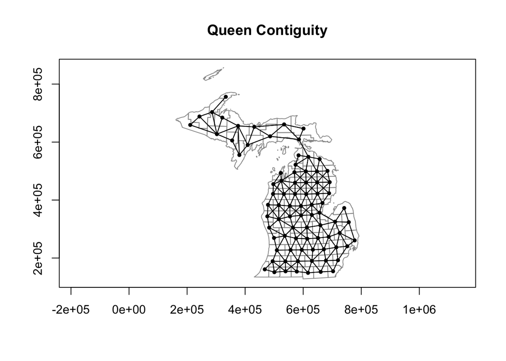

```r
mi_coords = st_point_on_surface(st_geometry(mi_county))
plot(st_geometry(mi_county), border="grey60", axes=T,  main="Queen Contiguity")
plot(mi_nb, mi_coords, pch=19, cex=0.6, add=T)
```

```r
# write.nb.gal(mi_nb, "mi_nb.gal", oldstyle=F)
(mi_nb_new = read.gal("mi_nb_new.gal"))
```

```
## Neighbour list object:
## Number of regions: 83
## Number of nonzero links: 422
## Percentage nonzero weights: 6.125708
## Average number of links: 5.084337
```

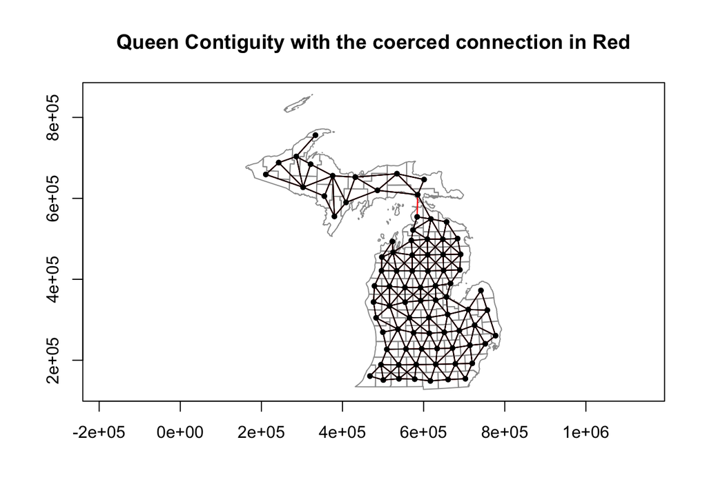

```r
plot(st_geometry(mi_county), border="grey60", axes=T,  main="Queen Contiguity with the coerced connection in Red")
plot(mi_nb_new, mi_coords, pch=19, cex=0.6, col="red", add=T)
plot(mi_nb, mi_coords, pch=19, cex=0.6, add=T)
```

3. Load the “covid.Rdata” file and give it spatial awareness using the Michigan county shapefile. (Hint: You will need to manipulate the “by” argument when mutating joins.) (4 marks)

```r
########################################
# Give spatial awareness to covid data #
########################################

load("covid.Rdata")
head(covid)
```

```
##     COUNTY TOT_CASES CASES_100K TOT_DEATHS DEATHS_100K PCT_VACC
## 1     Luce      1664      26714          6          96       42
## 2  Gratiot      9443      23195        139         341       42
## 3    Ionia     12794      19775        113         175       43
## 4 Chippewa      7291      19521         69         185       65
## 5 Montcalm     11727      18356        140         219       39
## 6   Branch      7907      18170        138         317       41
```

```r
(mi_covid = dplyr::inner_join(mi_county, covid, by=c("NAME"="COUNTY")))
```

```
## Simple feature collection with 83 features and 11 fields
## Geometry type: MULTIPOLYGON
## Dimension:     XY
## Bounding box:  xmin: 161503.6 ymin: 128066.9 xmax: 792243.2 ymax: 856671.3
## Projected CRS: NAD83 / Michigan Oblique Mercator
## First 10 features:
##    OBJECTID    NAME CNTY_CODE     SQKM    LAYOUT PENINSULA TOT_CASES
## 1         1  Alcona       001 1798.557 landscape     lower      1236
## 2         2   Alger       003 2424.879 landscape     upper      1064
## 3         3 Allegan       005 2180.969 landscape     lower     16489
## 4         4  Alpena       007 1539.373 landscape     lower      3662
## 5         5  Antrim       009 1358.721 landscape     lower      2650
## 6         6  Arenac       011  952.628 landscape     lower      1978
## 7         7  Baraga       013 2374.275  portrait     upper      1483
## 8         8   Barry       015 1493.487 landscape     lower      8756
## 9         9     Bay       017 1163.246  portrait     lower     16138
## 10       10  Benzie       019  899.702 landscape     lower      1866
##    CASES_100K TOT_DEATHS DEATHS_100K PCT_VACC                       geometry
## 1       11879         47         452       55 MULTIPOLYGON (((666667.5 48...
## 2       11682          9          99       59 MULTIPOLYGON (((414149.4 66...
## 3       13964        203         172       48 MULTIPOLYGON (((537474.7 20...
## 4       12892         79         278       52 MULTIPOLYGON (((711456.1 48...
## 5       11362         40         171       55 MULTIPOLYGON (((590912.3 47...
## 6       13290         38         255       48 MULTIPOLYGON (((667849.8 37...
## 7       18066         47         573       56 MULTIPOLYGON (((337205 6541...
## 8       14226         94         153       45 MULTIPOLYGON (((537056.1 24...
## 9       15649        411         399       53 MULTIPOLYGON (((647200 3654...
## 10      10503         41         231       63 MULTIPOLYGON (((514322.4 44...
```

4. Using a Moran’s I statistic, give a comparison of the spatial autocorrelation of the variables “CASES_100K” and “DEATHS_100K” in each county. (4 marks)

```r
#############
# Moran's I #
#############

(mi_lw = nb2listw(mi_nb_new))
```

```
## Characteristics of weights list object:
## Neighbour list object:
## Number of regions: 83
## Number of nonzero links: 422
## Percentage nonzero weights: 6.125708
## Average number of links: 5.084337
##
## Weights style: W
## Weights constants summary:
##    n   nn S0       S1       S2
## W 83 6889 83 36.16356 340.5086
```

```r
moran.test(mi_covid$CASES_100K, listw=mi_lw)
```

```
##
##  Moran I test under randomisation
##
## data:  mi_covid$CASES_100K
## weights: mi_lw
##
## Moran I statistic standard deviate = 3.8225, p-value = 6.605e-05
## alternative hypothesis: greater
## sample estimates:
## Moran I statistic       Expectation          Variance
##       0.248798647      -0.012195122       0.004661861
```

```r
moran.test(mi_covid$DEATHS_100K, listw=mi_lw)
```

```
##
##  Moran I test under randomisation
##
## data:  mi_covid$DEATHS_100K
## weights: mi_lw
##
## Moran I statistic standard deviate = 5.7846, p-value = 3.635e-09
## alternative hypothesis: greater
## sample estimates:
## Moran I statistic       Expectation          Variance
##       0.392512347      -0.012195122       0.004894831
```

```r
# Both Moran's I statistics are highly significant at 5% level.
# The death per 100k has a stronger spatial association compared to the cases per 100k.
```

5. Construct an appropriate plot to identify any significant local cluster(s) of counties with strong spatial spill-over effects in the “TOT_CASES” . What is the geographic/economic significance of the cluster(s) you observe? (4 marks)

```r
###################
# Local Moran's I #
###################

localm = localmoran(mi_covid$TOT_CASES, listw=mi_lw)
head(localm)
```

```
##             Ii          E.Ii       Var.Ii      Z.Ii Pr(z != E(Ii))
## 1 0.1937073260 -2.560953e-03 4.030897e-02 0.9775731      0.3282855
## 2 0.1687283627 -2.619148e-03 5.219738e-02 0.7499865      0.4532628
## 3 0.0006117184 -9.432433e-09 1.488461e-07 1.5855849      0.1128335
## 4 0.1765104999 -1.809781e-03 3.609665e-02 0.9385713      0.3479509
## 5 0.1562030202 -2.107318e-03 3.318393e-02 0.8690513      0.3848191
## 6 0.1309556652 -2.317397e-03 4.619772e-02 0.6200577      0.5352198
```

```r
mi_covid$LMORANZ = localm[,4]
tm_shape(mi_covid) + tm_polygons(col="LMORANZ")
```

```
## Variable(s) "LMORANZ" contains positive and negative values, so midpoint is set to 0. Set midpoint = NA to show the full spectrum of the color palette.
```

[interactive chart not shown]

```r
# There is a significant cluster of counties with high spatial autocorrelation in the number of the cases in the SE of Michigan.
# From a geographic/economic point of view, the cluster seems to surround Wayne county where Detroit is situated.
# Detroit is the largest and most populous city in the U.S. state of Michigan.
```

6. How many spatial outliers are there for the variable “TOT_DEATHS” per county? (4 marks)

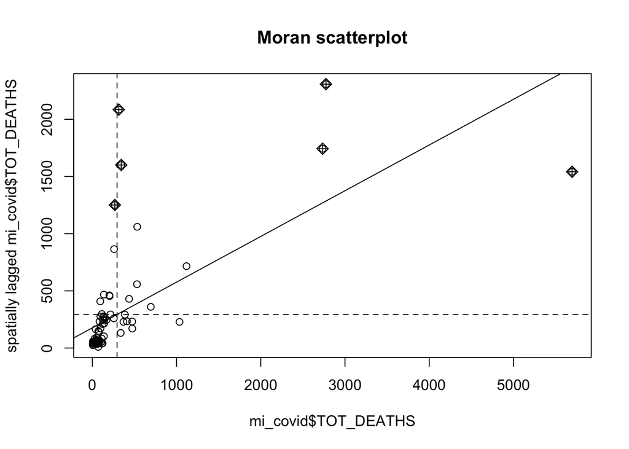

```r
##############
# Moran plot #
##############

moran_plot = moran.plot(mi_covid$TOT_DEATHS, listw=mi_lw, main="Moran scatterplot", labels=F)
```

```r
summary(moran_plot)
```

```
##        x                wx           is_inf           labels
##  Min.   :   6.0   Min.   :  10.0   Mode :logical   Length:83
##  1st Qu.:  47.0   1st Qu.:  56.8   FALSE:77        Class :character
##  Median :  94.0   Median : 103.0   TRUE :6         Mode  :character
##  Mean   : 293.6   Mean   : 294.0
##  3rd Qu.: 210.0   3rd Qu.: 275.6
##  Max.   :5696.0   Max.   :2307.5
##      dfb.1_              dfb.x               dffit               cov.r
##  Min.   :-0.115619   Min.   :-6.643393   Min.   :-6.706171   Min.   :0.4785
##  1st Qu.:-0.047318   1st Qu.:-0.001602   1st Qu.:-0.047238   1st Qu.:1.0333
##  Median :-0.041178   Median : 0.013159   Median :-0.041252   Median :1.0354
##  Mean   : 0.014728   Mean   :-0.050928   Mean   :-0.058524   Mean   :1.0285
##  3rd Qu.: 0.007178   3rd Qu.: 0.014817   3rd Qu.: 0.007792   3rd Qu.:1.0376
##  Max.   : 1.585483   Max.   : 1.319206   Max.   : 1.377340   Max.   :1.6970
##      cook.d               hat
##  Min.   : 0.000000   Min.   :0.01206
##  1st Qu.: 0.000516   1st Qu.:0.01260
##  Median : 0.001005   Median :0.01313
##  Mean   : 0.227026   Mean   :0.02410
##  3rd Qu.: 0.001505   3rd Qu.:0.01344
##  Max.   :17.415351   Max.   :0.64655
```

```r
library(dplyr)
(high_low = moran_plot %>% filter(x > 293.6) %>% filter(wx < 294))
```

```
##       x       wx is_inf labels      dfb.1_        dfb.x       dffit    cov.r
## 9   411 233.2000  FALSE      9 -0.02953821 -0.005340970 -0.03427675 1.035539
## 11  337 132.0000  FALSE     11 -0.05126336 -0.003290740 -0.05649882 1.030967
## 13  369 228.8571  FALSE     13 -0.02673794 -0.003033570 -0.03009135 1.035884
## 33  473 231.6000  FALSE     33 -0.03550873 -0.010166326 -0.04338677 1.034620
## 38  386 292.1429  FALSE     38 -0.01078611 -0.001513731 -0.01228501 1.037537
## 39  474 170.1429  FALSE     39 -0.05190555 -0.014952391 -0.06347804 1.030353
## 41 1035 228.7143  FALSE     41 -0.06536648 -0.115240600 -0.16330658 1.022452
##          cook.d        hat
## 9  5.940930e-04 0.01234800
## 11 1.610757e-03 0.01208920
## 13 4.579832e-04 0.01217190
## 33 9.512377e-04 0.01274813
## 38 7.639232e-05 0.01223394
## 39 2.031994e-03 0.01275595
## 41 1.332061e-02 0.02399898
```

```r
(low_high = moran_plot %>% filter(x < 293.6) %>% filter(wx > 294))
```

```
##      x        wx is_inf labels     dfb.1_        dfb.x      dffit     cov.r
## 3  203  460.4000  FALSE      3 0.06213816 -0.007753989 0.06420724 1.0292575
## 8   94  408.1667  FALSE      8 0.06279262 -0.016364566 0.06320072 1.0306864
## 34 113  297.5000  FALSE     34 0.02423443 -0.005766993 0.02446590 1.0372016
## 44 267 1250.5000   TRUE     44 0.30096021 -0.011384693 0.31922895 0.8508851
## 47 258  865.1667  FALSE     47 0.17725893 -0.008934931 0.18723330 0.9671030
## 78 137  467.3333  FALSE     78 0.07485391 -0.015626483 0.07592703 1.0265734
## 79 205  454.3333  FALSE     79 0.05996266 -0.007324683 0.06200225 1.0298206
##          cook.d        hat
## 3  0.0020783982 0.01222651
## 8  0.0020144424 0.01291401
## 34 0.0003028558 0.01275699
## 44 0.0467169520 0.01206354
## 47 0.0171330384 0.01207569
## 78 0.0029020747 0.01258110
## 79 0.0019386353 0.01221872
```